### 1.2. Calcul du Score de Consommation Alimentaire

Poids attribués aux groupes alimentaires pour le calcul du SCA

| groupe_alimentaire | variable | poids |
| --- | --- | --- |
| Céréales/Tubercules | Food_div1 | 2.0 |
| Légumineuses | Food_div2 | 3.0 |
| Produits laitiers | Food_div3 | 4.0 |
| Viande/Poisson/Œufs | Food_div4 | 4.0 |
| Légumes | Food_div5 | 1.0 |
| Fruits | Food_div6 | 1.0 |
| Huile/Graisse | Food_div7 | 0.5 |
| Sucre | Food_div8 | 0.5 |

```
   Min. 1st Qu.  Median    Mean 3rd Qu.    Max.    NA's
   0.00    6.00   14.00   16.46   23.00  107.00      23
```

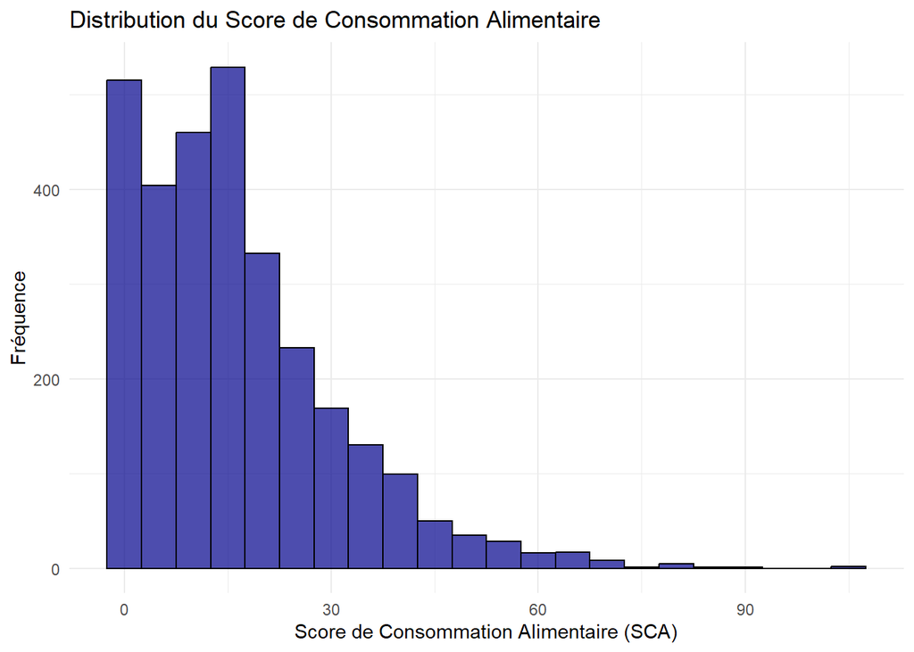

### 1.3. Catégorisation du SCA selon différents seuils

Répartition des ménages selon les seuils SCA 21/35

| categorie_sca_21_35 | n | proportion |
| --- | --- | --- |
| Acceptable | 311 | 10.1700458 |
| Limite | 626 | 20.4708960 |
| Pauvre | 2098 | 68.6069326 |
| NA | 23 | 0.7521256 |

Répartition des ménages selon les seuils SCA 28/42

| categorie_sca_28_42 | n | proportion |
| --- | --- | --- |
| Acceptable | 169 | 5.5264879 |
| Limite | 393 | 12.8515370 |
| Pauvre | 2473 | 80.8698496 |
| NA | 23 | 0.7521256 |

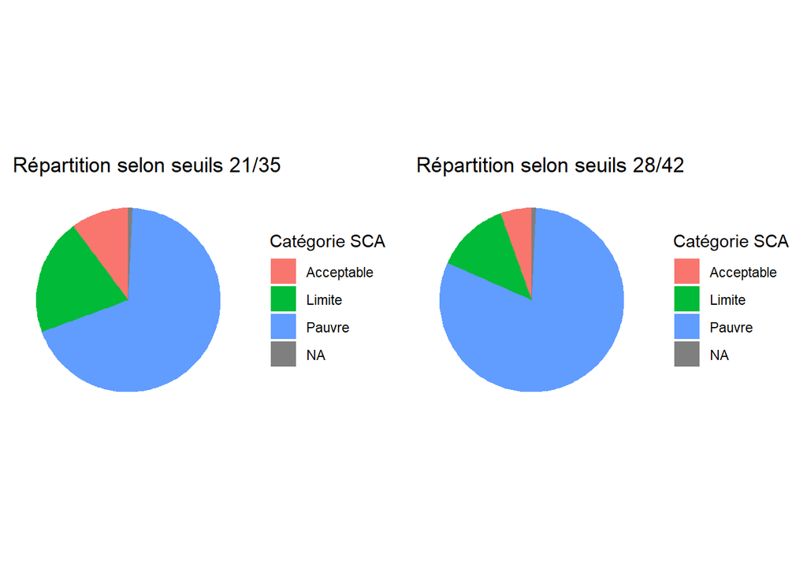

### 1.4. Représentation spatiale du SCA par région et département

Score de Consommation Alimentaire par région

| admin1 | sca_moyen | sca_median | n | pct_pauvre_21_35 | pct_limite_21_35 | pct_acceptable_21_35 |
| --- | --- | --- | --- | --- | --- | --- |
| Unity | 16.8 | 14.0 | 1064 | 69.9 | 22.6 | 7.5 |
| Upper Nile | 14.5 | 10.2 | 1466 | 74.5 | 15.1 | 10.5 |
| Central Equatoria | 27.3 | 25.0 | 114 | 34.5 | 36.3 | 29.2 |
| Jonglei | 8.0 | 7.0 | 35 | 96.4 | 3.6 | 0.0 |
| Western Equatoria | 21.4 | 20.5 | 285 | 50.2 | 36.8 | 13.0 |
| NA | 18.0 | 14.5 | 94 | 68.5 | 21.7 | 9.8 |

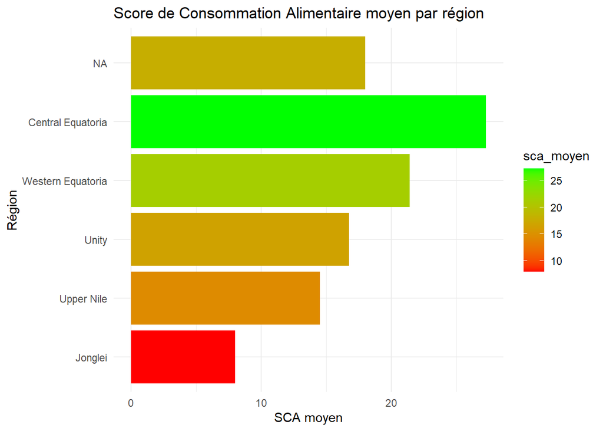

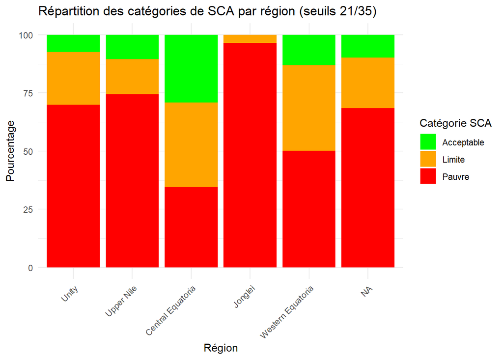

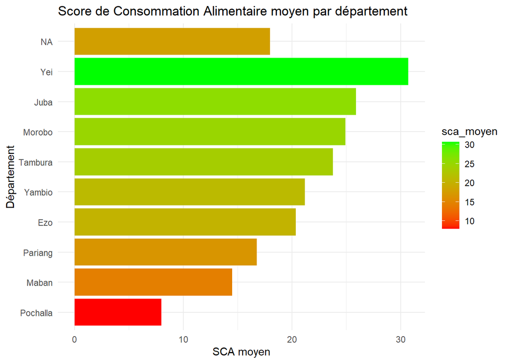

### 1.5. Analyse du SCA selon le statut de déplacement

Score de Consommation Alimentaire par statut de déplacement

| Intro_07_1 | sca_moyen | sca_median | sca_ecart_type | n | pct_pauvre_21_35 | pct_limite_21_35 | pct_acceptable_21_35 |
| --- | --- | --- | --- | --- | --- | --- | --- |
| Refugees | 16.4 | 14 | 14.2 | 2068 | 67.5 | 22.5 | 10.0 |
| Host community North | 16.6 | 14 | 14.6 | 990 | 72.4 | 16.8 | 10.8 |

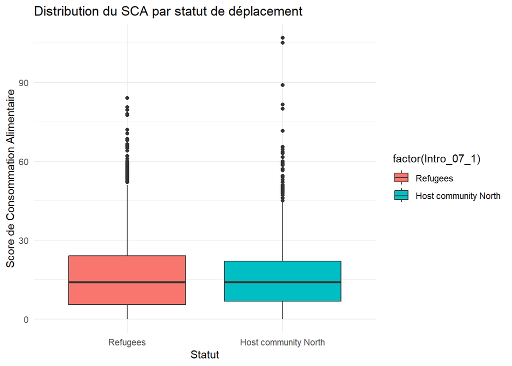

```
Test ANOVA pour comparer les moyennes du SCA entre les groupes:
                     Df Sum Sq Mean Sq F value Pr(>F)
factor(Intro_07_1)    1     19   18.53   0.091  0.764
Residuals          3033 620829  204.69
23 observations effacées parce que manquantes
```

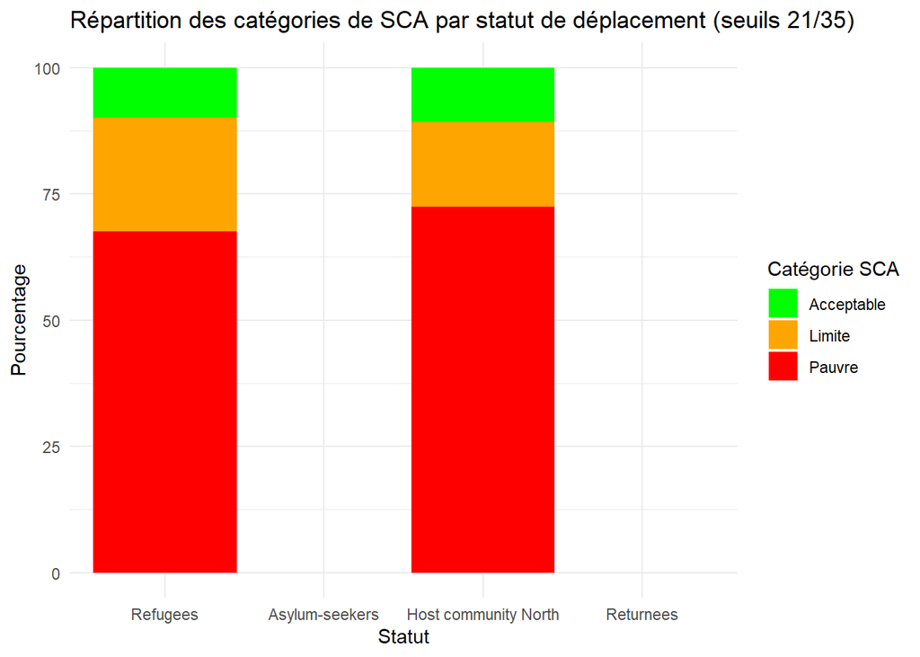

# V L’indice réduit des stratégies de survie (rCSI)

L’indice réduit des stratégies de survie (rCSI) est un indicateur qui mesure les comportements d’adaptation que les ménages adoptent lorsqu’ils n’ont pas accès à suffisamment de nourriture. Il est basé sur un ensemble de cinq stratégies de survie communes liées à la consommation alimentaire. Un score plus élevé indique une plus grande insécurité alimentaire.

## 1. Analyse descriptive des variables qui composent le rCSI

Les cinq stratégies d’adaptation communes utilisées pour calculer le rCSI sont:

1. Consommer des aliments moins préférés et moins chers (Food02a)
2. Emprunter de la nourriture ou compter sur l’aide de proches (Food05a)
3. Limiter la taille des portions au moment des repas (Food06a)
4. Réduire le nombre de repas par jour (Food08a)
5. Réduire la consommation des adultes pour nourrir les enfants (Food07a)

```
tibble [3,058 × 5] (S3: tbl_df/tbl/data.frame)
 $ Food02a: Factor w/ 2 levels "yes","no": 1 2 1 1 1 1 1 1 1 1 ...
  ..- attr(*, "label")= chr "A member ate less preferred food and less expensive food [Past 30/7 days]"
 $ Food05a: Factor w/ 2 levels "yes","no": 1 2 2 1 2 2 1 1 2 2 ...
  ..- attr(*, "label")= chr "Any member borrowed food/relied on help to get more food...[Past 30/7 days]"
 $ Food06a: Factor w/ 2 levels "yes","no": 1 2 1 1 1 1 1 1 2 2 ...
  ..- attr(*, "label")= chr "Any member ate a smaller meal than you felt you needed [Past 30/7 days]"
 $ Food08a: Factor w/ 2 levels "yes","no": 1 2 1 1 1 1 1 1 1 2 ...
  ..- attr(*, "label")= chr "Any member ate fewer meals in a day [Past 30/7 days]"
 $ Food07a: Factor w/ 2 levels "yes","no": 1 2 1 1 1 1 2 2 1 2 ...
  ..- attr(*, "label")= chr "Adults ate less to have more food for children under 5? [Past 30/7 days]"
```

```
Variable: Food02a

 yes   no <NA>
2493  563    2

Variable: Food05a

 yes   no <NA>
1831 1222    5

Variable: Food06a

 yes   no <NA>
2600  454    4

Variable: Food08a

 yes   no <NA>
2547  510    1

Variable: Food07a

 yes   no <NA>
2145  906    7
```

Statistiques descriptives des variables du rCSI

[output not shown]

[figure not shown]

## 2. Création et analyse de nouvelles variables numériques pour le rCSI

Statistiques descriptives des nouvelles variables numériques du rCSI

| variable | moyenne | mediane | type | min | max |
| --- | --- | --- | --- | --- | --- |
| Food02a_num | 0 | 0 | NA | 0 | 0 |
| Food02a_num_ecart | NA | NA | 0 | NA | NA |
| Food05a_num | 0 | 0 | NA | 0 | 0 |
| Food05a_num_ecart | NA | NA | 0 | NA | NA |
| Food06a_num | 0 | 0 | NA | 0 | 0 |
| Food06a_num_ecart | NA | NA | 0 | NA | NA |
| Food08a_num | 0 | 0 | NA | 0 | 0 |
| Food08a_num_ecart | NA | NA | 0 | NA | NA |
| Food07a_num | 0 | 0 | NA | 0 | 0 |
| Food07a_num_ecart | NA | NA | 0 | NA | NA |

[figure not shown]

## 3. Calcul de l’indice réduit des stratégies de survie (rCSI)

```
[1] 21
```

Poids attribués aux stratégies pour le calcul du rCSI

| strategie | variable | poids |
| --- | --- | --- |
| Aliments moins préférés | Food02a_num | 2 |
| Emprunter nourriture | Food05a_num | 2 |
| Limiter portions | Food06a_num | 3 |
| Réduire repas | Food08a_num | 7 |
| Adultes mangent moins | Food07a_num | 7 |

```
   Min. 1st Qu.  Median    Mean 3rd Qu.    Max.    NA's
      0       0       0       0       0       0      15
```

[figure not shown]

Répartition des ménages par niveau de stress alimentaire

| categorie_rcsi | n | proportion |
| --- | --- | --- |
| Faible | 3043 | 99.5094833 |
| NA | 15 | 0.4905167 |

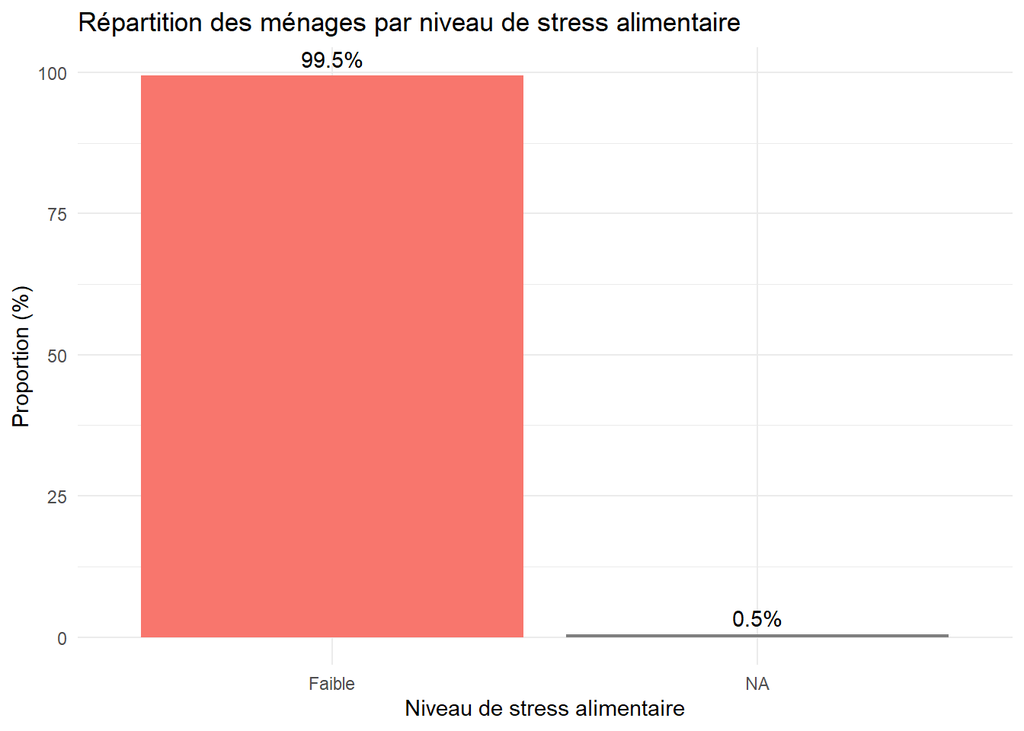

## 4. Représentation spatiale du rCSI selon le milieu de résidence

rCSI moyen par milieu de résidence

| Intro_09 | rcsi_moyen | rcsi_median | rcsi_ecart_type | n |
| --- | --- | --- | --- | --- |
| rural | 0 | 0 | 0 | 2058 |
| peri-urban | 0 | 0 | 0 | 740 |
| urban | 0 | 0 | 0 | 258 |
| NA | 0 | 0 | 0 | 2 |

[figure not shown]

[figure not shown]

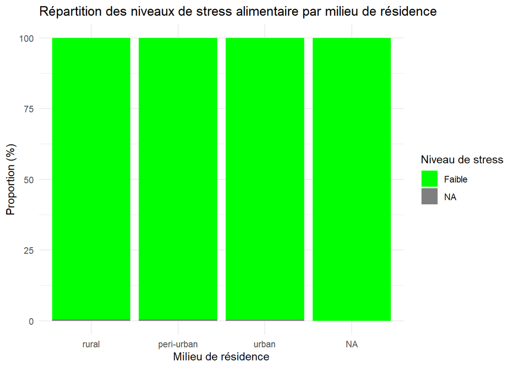

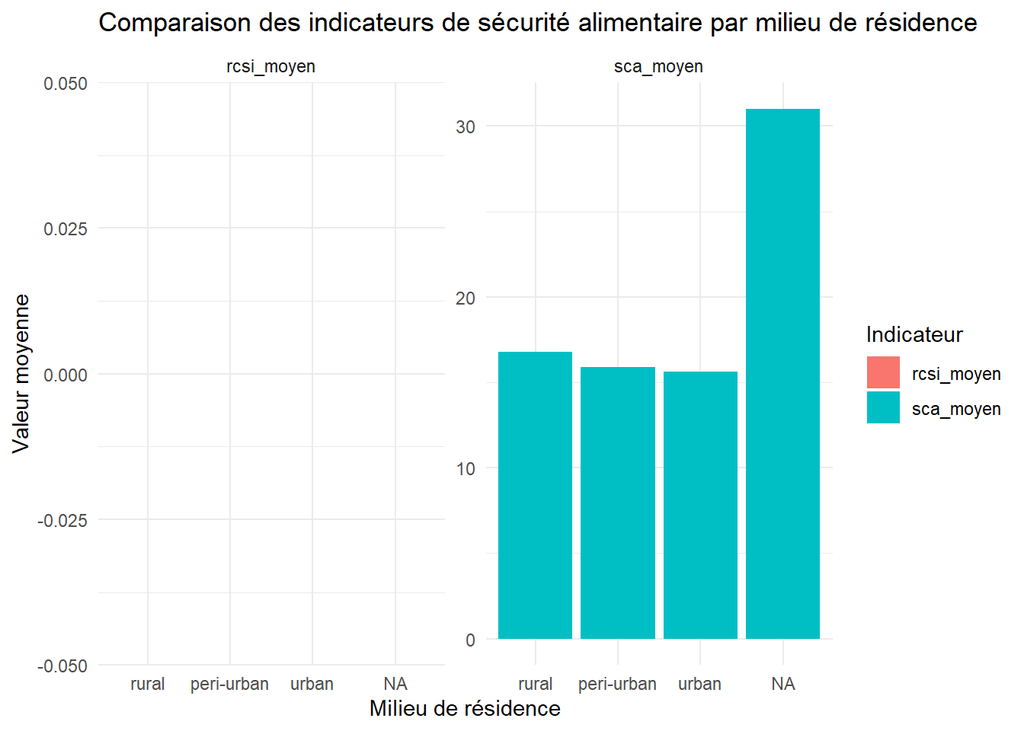

## 5. Analyse croisée du rCSI avec d’autres variables socio-démographiques

rCSI moyen par groupe de population

| Intro_07_1 | rcsi_moyen | rcsi_median | n | pct_eleve |
| --- | --- | --- | --- | --- |
| Refugees | 0 | 0 | 2068 | 0 |
| Host community North | 0 | 0 | 990 | 0 |

[figure not shown]

```
Test ANOVA pour comparer les moyennes du rCSI entre les groupes:
                     Df Sum Sq Mean Sq F value Pr(>F)
factor(Intro_07_1)    1      0       0     NaN    NaN
Residuals          3041      0       0
15 observations effacées parce que manquantes
```